# Racial and ethnic disparities in data exclusion are present at baseline, but not at the 2-year follow up:

# summary of longitudinal full model:

```r
summary(longitudinal_full_model)
```

```
## Generalized linear mixed model fit by maximum likelihood (Laplace
##   Approximation) [glmerMod]
##  Family: binomial  ( logit )
## Formula: exclude ~ income_z + parent_ed_z + female + race_ethnicity_label +
##     eventname + age_z + (1 | rel_family_id/src_subject_id) +      (1 | site)
##    Data: longitudinal_data
## Control: CONFIG$model_control
##
##      AIC      BIC   logLik deviance df.resid
##  10517.5  10610.3  -5245.7  10491.5     9303
##
## Scaled residuals:
##     Min      1Q  Median      3Q     Max
## -1.6362 -0.5606 -0.3902  0.7013  2.7258
##
## Random effects:
##  Groups                       Name        Variance Std.Dev.
##  src_subject_id:rel_family_id (Intercept) 0.5401   0.7349
##  rel_family_id                (Intercept) 0.7631   0.8735
##  site                         (Intercept) 0.1509   0.3884
## Number of obs: 9316, groups:
## src_subject_id:rel_family_id, 4658; rel_family_id, 4061; site, 21
##
## Fixed effects:
##                                Estimate Std. Error z value Pr(>|z|)
## (Intercept)                    -1.36472    0.11010 -12.396  < 2e-16 ***
## income_z                       -0.03610    0.04588  -0.787   0.4313
## parent_ed_z                    -0.08580    0.04665  -1.839   0.0659 .
## female                         -0.53121    0.06565  -8.092 5.87e-16 ***
## race_ethnicity_labelBlack       0.23278    0.12312   1.891   0.0587 .
## race_ethnicity_labelHispanic    0.19959    0.10456   1.909   0.0563 .
## race_ethnicity_labelAsian       0.14759    0.27213   0.542   0.5876
## race_ethnicity_labelOther       0.05582    0.11334   0.493   0.6223
## eventnamebaseline_year_1_arm_1  0.99237    0.05719  17.353  < 2e-16 ***
## age_z                          -0.27025    0.03304  -8.180 2.84e-16 ***
## ---
## Signif. codes:  0 '***' 0.001 '**' 0.01 '*' 0.05 '.' 0.1 ' ' 1
##
## Correlation of Fixed Effects:
##             (Intr) incm_z prnt__ female rc_t_B rc_t_H rc_t_A rc_t_O e__1__
## income_z    -0.064
## parent_ed_z -0.053 -0.509
## female      -0.207  0.009 -0.006
## rc_thncty_B -0.218  0.303  0.072 -0.024
## rc_thncty_H -0.257  0.131  0.181 -0.031  0.276
## rc_thncty_A -0.084  0.012 -0.047 -0.003  0.047  0.082
## rc_thncty_O -0.174  0.096  0.024 -0.021  0.208  0.220  0.069
## evntn__1__1 -0.337 -0.017 -0.029 -0.080  0.014  0.013  0.006  0.003
## age_z        0.042  0.004  0.015  0.096 -0.025 -0.008 -0.015  0.002 -0.066
```

# summary of longitudinal reduced model:

```r
summary(longitudinal_reduced_model)
```

```
## Generalized linear mixed model fit by maximum likelihood (Laplace
##   Approximation) [glmerMod]
##  Family: binomial  ( logit )
## Formula: exclude ~ income_z + parent_ed_z + female + eventname + age_z +
##     (1 | rel_family_id/src_subject_id) + (1 | site)
##    Data: longitudinal_data
## Control: CONFIG$model_control
##
##      AIC      BIC   logLik deviance df.resid
##  10515.3  10579.5  -5248.6  10497.3     9307
##
## Scaled residuals:
##     Min      1Q  Median      3Q     Max
## -1.6049 -0.5634 -0.3900  0.6977  2.6715
##
## Random effects:
##  Groups                       Name        Variance Std.Dev.
##  src_subject_id:rel_family_id (Intercept) 0.5393   0.7344
##  rel_family_id                (Intercept) 0.7672   0.8759
##  site                         (Intercept) 0.1564   0.3955
## Number of obs: 9316, groups:
## src_subject_id:rel_family_id, 4658; rel_family_id, 4061; site, 21
##
## Fixed effects:
##                                Estimate Std. Error z value Pr(>|z|)
## (Intercept)                    -1.29036    0.10563 -12.215  < 2e-16 ***
## income_z                       -0.06552    0.04364  -1.501   0.1332
## parent_ed_z                    -0.10283    0.04579  -2.246   0.0247 *
## female                         -0.52771    0.06563  -8.040 8.97e-16 ***
## eventnamebaseline_year_1_arm_1  0.99315    0.05719  17.365  < 2e-16 ***
## age_z                          -0.26935    0.03304  -8.152 3.59e-16 ***
## ---
## Signif. codes:  0 '***' 0.001 '**' 0.01 '*' 0.05 '.' 0.1 ' ' 1
##
## Correlation of Fixed Effects:
##             (Intr) incm_z prnt__ female e__1__
## income_z     0.015
## parent_ed_z -0.008 -0.577
## female      -0.228  0.019  0.000
## evntn__1__1 -0.346 -0.022 -0.032 -0.080
## age_z        0.038  0.011  0.017  0.096 -0.066
```

## bayes factor for longtiduinal model:

```r
bf_result_longitudinal = bayesfactor_models(longitudinal_full_model, longitudinal_reduced_model,
                                            denominator = longitudinal_reduced_model)
print(bf_result_longitudinal)
```

```
## Bayes Factors for Model Comparison
##
##
## [longitudinal_full_model]
##
## Model
## income_z + parent_ed_z + female + race_ethnicity_label + eventname + age_z + (1 | src_subject_id:rel_family_id) + (1 | rel_family_id) + (1 | site)
##
##       BF
## 2.10e-07
##
## * Against Denominator: [longitudinal_reduced_model] income_z + parent_ed_z + female + eventname + age_z + (1 | src_subject_id:rel_family_id) + (1 | rel_family_id) + (1 | site)
## *   Bayes Factor Type: BIC approximation
```

## 8. plotting exclusion at baseline:

**At baseline, exclusion due to high-motion rates on the full sample (n = 8561) were highest for Black participants (48.3%), followed by Hispanic (44.8%), Asian (43.5%), Other (37.9%) and White (35.4%) participants (Fig. 3, top). At the 2-year follow-up (n = 5789), overall exclusion rates declined across all groups, consistent with decreased motion across child development as well as increased exclusion and loss to followup for high-motion individuals.**

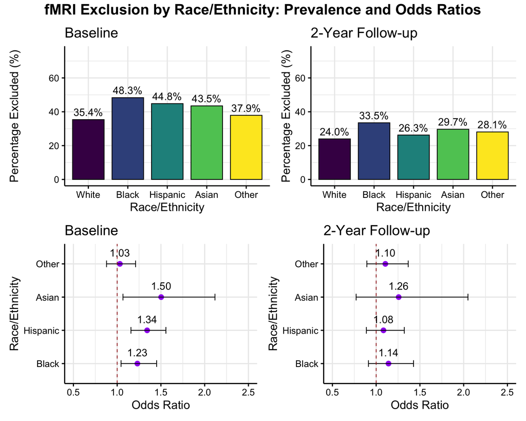

```r
# Calculate exclusion summaries
exclusion_summary_baseline <- baseline_data %>%
  group_by(race_ethnicity_label) %>%
  summarise(
    n = n(),
    n_excluded = sum(exclude == 1, na.rm = TRUE),
    percent_excluded = 100 * n_excluded / n,
    .groups = "drop"
  )

exclusion_summary_followup <- followup_data %>%
  group_by(race_ethnicity_label) %>%
  summarise(
    n = n(),
    n_excluded = sum(exclude == 1, na.rm = TRUE),
    percent_excluded = 100 * n_excluded / n,
    .groups = "drop"
  )

# Set consistent factor levels
race_levels <- c("White", "Black", "Hispanic", "Asian", "Other")
exclusion_summary_baseline$race_ethnicity_label <- factor(exclusion_summary_baseline$race_ethnicity_label, levels = race_levels)
exclusion_summary_followup$race_ethnicity_label <- factor(exclusion_summary_followup$race_ethnicity_label, levels = race_levels)

# Create baseline exclusion plot
plot_baseline_exclusion <- ggplot(exclusion_summary_baseline, aes(x = race_ethnicity_label, y = percent_excluded, fill = race_ethnicity_label)) +
  geom_col(show.legend = FALSE, width = 0.8, color = "black") +
  geom_text(aes(label = sprintf("%.1f%%", percent_excluded)), vjust = -0.5, size = 5, color = "black") +
  labs(
    title = "Baseline",
    x = "Race/Ethnicity",
    y = "Percentage Excluded (%)"
  ) +
  ylim(0, 75) +
  scale_fill_viridis_d(option = "D") +
  theme_minimal(base_size = 16) +
  theme(
    axis.text = element_text(color = "black"),
    axis.title = element_text(color = "black"),
    axis.ticks = element_line(color = "black"),
    axis.line = element_line(color = "black")
  )

# Create follow-up exclusion plot
plot_followup_exclusion <- ggplot(exclusion_summary_followup, aes(x = race_ethnicity_label, y = percent_excluded, fill = race_ethnicity_label)) +
  geom_col(show.legend = FALSE, width = 0.8, color = "black") +
  geom_text(aes(label = sprintf("%.1f%%", percent_excluded)), vjust = -0.5, size = 5, color = "black") +
  labs(
    title = "2-Year Follow-up",
    x = "Race/Ethnicity",
    y = "Percentage Excluded (%)"
  ) +
  ylim(0, 75) +
  scale_fill_viridis_d(option = "D") +
  theme_minimal(base_size = 16) +
  theme(
    axis.text = element_text(color = "black"),
    axis.title = element_text(color = "black"),
    axis.ticks = element_line(color = "black"),
    axis.line = element_line(color = "black")
  )

# Extract odds ratios for plotting
if (baseline_full_converged) {
  or_baseline <- extract_odds_ratios(baseline_full_model, "Baseline")
  or_baseline$race_ethnicity_label <- factor(or_baseline$race_ethnicity_label, levels = race_levels[-1])
}

if (followup_full_converged) {
  or_followup <- extract_odds_ratios(followup_full_model, "Follow-up")
  or_followup$race_ethnicity_label <- factor(or_followup$race_ethnicity_label, levels = race_levels[-1])
}

# Create odds ratio plots
if (exists("or_baseline") && nrow(or_baseline) > 0) {
  plot_or_baseline <- ggplot(or_baseline, aes(x = estimate, y = race_ethnicity_label)) +
    geom_point(color = "purple", size = 3) +
    geom_errorbarh(aes(xmin = conf.low, xmax = conf.high), height = 0.2, color = "black") +
    geom_vline(xintercept = 1, linetype = "dashed", color = "brown") +
    geom_text(aes(label = sprintf("%.2f", estimate)), vjust = -1, size = 5, color = "black") +
    scale_x_continuous(limits = c(0.5, 2.5), breaks = seq(0.5, 2.5, 0.5)) +
    labs(
      title = "Baseline",
      x = "Odds Ratio",
      y = "Race/Ethnicity"
    ) +
    theme_minimal(base_size = 16) +
    theme(
      axis.text = element_text(color = "black"),
      axis.title = element_text(color = "black"),
      axis.ticks = element_line(color = "black"),
      axis.line = element_line(color = "black")
    )
}

if (exists("or_followup") && nrow(or_followup) > 0) {
  plot_or_followup <- ggplot(or_followup, aes(x = estimate, y = race_ethnicity_label)) +
    geom_point(color = "purple", size = 3) +
    geom_errorbarh(aes(xmin = conf.low, xmax = conf.high), height = 0.2, color = "black") +
    geom_vline(xintercept = 1, linetype = "dashed", color = "brown") +
    geom_text(aes(label = sprintf("%.2f", estimate)), vjust = -1, size = 5, color = "black") +
    scale_x_continuous(limits = c(0.5, 2.5), breaks = seq(0.5, 2.5, 0.5)) +
    labs(
      title = "2-Year Follow-up",
      x = "Odds Ratio",
      y = "Race/Ethnicity"
    ) +
    theme_minimal(base_size = 16) +
    theme(
      axis.text = element_text(color = "black"),
      axis.title = element_text(color = "black"),
      axis.ticks = element_line(color = "black"),
      axis.line = element_line(color = "black")
    )
}

# Combine plots
if (exists("plot_or_baseline") && exists("plot_or_followup")) {
  combined_exclusion_plot <- (plot_baseline_exclusion | plot_followup_exclusion) /
                            (plot_or_baseline | plot_or_followup) +
    plot_annotation(
      title = "fMRI Exclusion by Race/Ethnicity: Prevalence and Odds Ratios",
      theme = theme(plot.title = element_text(size = 20, face = "bold", hjust = 0.5))
    )

  print(combined_exclusion_plot)

  # Save plot
  ggsave(
    filename = "exclusion_oddsratio.svg",
    plot = combined_exclusion_plot,
    path = CONFIG$output_dir,
    width = 12,
    height = 10,
    units = "in"
  )
}
```

## create demographic tables:

```r
cat("=== Creating Demographic Tables ===\n")
```

```
## === Creating Demographic Tables ===
```

```r
# Prepare variables for tables
demographic_vars <- c("age_z", "sex", "race_ethnicity_label", "income", "parental_education")
categorical_vars <- c("sex", "race_ethnicity_label", "income", "parental_education")

# Convert age back to numeric for table
baseline_data$age_numeric <- as.numeric(baseline_data$age_z)
followup_data$age_numeric <- as.numeric(followup_data$age_z)

# Create baseline demographics table
baseline_table <- CreateTableOne(
  vars = c("age_numeric", demographic_vars[-1]),
  strata = "exclude",
  data = baseline_data,
  factorVars = categorical_vars
)

print(baseline_table, showAllLevels = TRUE, quote = FALSE, noSpaces = TRUE, test = TRUE)
```

```
##                           Stratified by exclude
##                            level    0           1            p      test
##   n                                 5203        3358
##   age_numeric (mean (SD))           0.08 (1.00) -0.13 (0.98) <0.001
##   sex (%)                  1        2486 (47.8) 1807 (53.8)  <0.001
##                            2        2717 (52.2) 1550 (46.2)
##                            3        0 (0.0)     1 (0.0)
##   race_ethnicity_label (%) White    3093 (59.4) 1692 (50.4)  <0.001
##                            Black    556 (10.7)  520 (15.5)
##                            Hispanic 909 (17.5)  738 (22.0)
##                            Asian    91 (1.7)    70 (2.1)
##                            Other    554 (10.6)  338 (10.1)
##   income (%)               1        136 (2.6)   136 (4.1)    <0.001
##                            2        136 (2.6)   149 (4.4)
##                            3        105 (2.0)   110 (3.3)
```

[output cut: 26 more lines]

# print 2yr follow up table:

```r
# Create follow-up demographics table
followup_table <- CreateTableOne(
  vars = c("age_numeric", demographic_vars[-1]),
  strata = "exclude",
  data = followup_data,
  factorVars = categorical_vars
)

print(followup_table, showAllLevels = TRUE, quote = FALSE, noSpaces = TRUE, test = TRUE)
```

```
##                           Stratified by exclude
##                            level    0           1            p      test
##   n                                 4287        1502
##   age_numeric (mean (SD))           0.05 (1.01) -0.14 (0.95) <0.001
##   sex (%)                  1        2140 (49.9) 930 (61.9)   <0.001
##                            2        2147 (50.1) 572 (38.1)
##   race_ethnicity_label (%) White    2581 (60.2) 813 (54.1)   <0.001
##                            Black    427 (10.0)  215 (14.3)
##                            Hispanic 795 (18.5)  283 (18.8)
##                            Asian    64 (1.5)    27 (1.8)
##                            Other    420 (9.8)   164 (10.9)
##   income (%)               1        80 (1.9)    60 (4.0)     <0.001
##                            2        106 (2.5)   46 (3.1)
##                            3        69 (1.6)    31 (2.1)
##                            4        147 (3.4)   52 (3.5)
##                            5        231 (5.4)   89 (5.9)
##                            6        287 (6.7)   124 (8.3)
##                            7        599 (14.0)  205 (13.6)
##                            8        638 (14.9)  203 (13.5)
##                            9        1510 (35.2) 508 (33.8)
##                            10       620 (14.5)  184 (12.3)
##   parental_education (%)   4        1 (0.0)     0 (0.0)      0.003
##                            6        6 (0.1)     2 (0.1)
##                            7        3 (0.1)     1 (0.1)
##                            8        9 (0.2)     0 (0.0)
##                            9        26 (0.6)    8 (0.5)
##                            10       25 (0.6)    11 (0.7)
##                            11       28 (0.7)    17 (1.1)
##                            12       42 (1.0)    13 (0.9)
##                            13       197 (4.6)   96 (6.4)
##                            14       75 (1.7)    41 (2.7)
##                            15       516 (12.0)  211 (14.0)
##                            16       308 (7.2)   113 (7.5)
##                            17       240 (5.6)   85 (5.7)
##                            18       1196 (27.9) 386 (25.7)
##                            19       1124 (26.2) 389 (25.9)
##                            20       250 (5.8)   58 (3.9)
##                            21       241 (5.6)   71 (4.7)
```

# export tables to word doc:

```r
# Export tables to Word documents
tryCatch({
  # Baseline table
  baseline_table_matrix <- print(baseline_table, showAllLevels = TRUE, quote = FALSE,
                                noSpaces = TRUE, printToggle = FALSE, test = TRUE)
  baseline_table_df <- as.data.frame(baseline_table_matrix)
  baseline_flextable <- flextable(baseline_table_df)

  save_as_docx(
    baseline_flextable,
    path = file.path(CONFIG$output_dir, "baseline_demographics_table.docx")
  )

  # Follow-up table
  followup_table_matrix <- print(followup_table, showAllLevels = TRUE, quote = FALSE,
                                noSpaces = TRUE, printToggle = FALSE, test = TRUE)
  followup_table_df <- as.data.frame(followup_table_matrix)
  followup_flextable <- flextable(followup_table_df)

  save_as_docx(
    followup_flextable,
    path = file.path(CONFIG$output_dir, "followup_demographics_table.docx")
  )

  cat("✓ Demographic tables saved to", CONFIG$output_dir, "\n")

}, error = function(e) {
  cat("⚠️ Failed to save demographic tables:", e$message, "\n")
})
```

```
## ✓ Demographic tables saved to /Users/ricard/Desktop/poldrack/projects/head-motion-exclusion/outputs
```

## 9. consort flow diagram

```r
#dairc_data loaded in only for the purposes of this consort diagram.
dairc_data_baseline <- prepare_timepoint_data(
  dairc_data,
  "baseline",
  "baseline_year_1_arm_1"
)
```

```
## Preparing baseline data...
## ✓ baseline : 11868 → 10280 participants ( 1588 removed due to missing data)
```

```r
dairc_data_followup <- prepare_timepoint_data(
  dairc_data,
  "followup",
  "2_year_follow_up_y_arm_1"
)
```

```
## Preparing followup data...
## ✓ followup : 10908 → 6538 participants ( 4370 removed due to missing data)
```

```r
cat("=== Creating CONSORT Flow Diagrams ===\n")
```

```
## === Creating CONSORT Flow Diagrams ===
```

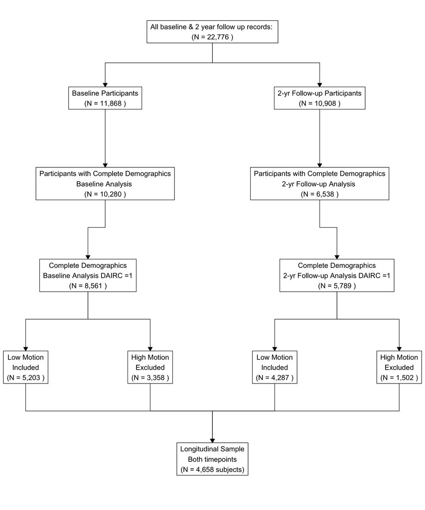

```r
baseline_data_n = nrow(baseline_data)
followup_data_n = nrow(followup_data)

dairc_data_full <- sum(dairc_data$eventname == "baseline_year_1_arm_1" |
                       dairc_data$eventname == "2_year_follow_up_y_arm_1", na.rm = TRUE)
# Calculate flow numbers from dairc_data (from another script)
baseline_raw_n <- sum(dairc_data$eventname == "baseline_year_1_arm_1", na.rm = TRUE)
followup_raw_n <- sum(dairc_data$eventname == "2_year_follow_up_y_arm_1", na.rm = TRUE)

# Calculate DAIRC = 1 counts from dairc_data (these should be 10,280 and 6,538)
baseline_dairc_n <- sum(dairc_data$eventname == "baseline_year_1_arm_1" &
                       dairc_data$imgincl_rsfmri_include == 1, na.rm = TRUE)

followup_dairc_n <- sum(dairc_data$eventname == "2_year_follow_up_y_arm_1" &
                       dairc_data$imgincl_rsfmri_include == 1, na.rm = TRUE)

# Calculate exclusions for baseline analysis
baseline_excluded_motion <- sum(baseline_data$exclude == 1, na.rm = TRUE)
baseline_included_final <- sum(baseline_data$exclude == 0, na.rm = TRUE)

# Calculate exclusions for follow-up analysis
followup_excluded_motion <- sum(followup_data$exclude == 1, na.rm = TRUE)
followup_included_final <- sum(followup_data$exclude == 0, na.rm = TRUE)

dairc_data_baseline_n <- nrow(dairc_data_baseline)
dairc_data_followup_n <- nrow(dairc_data_followup)

consort_exclusion <- add_box(txt = paste("All baseline & 2 year follow up records: \n(N =", format(dairc_data_full, big.mark = ","), ")")) %>%

  add_split(txt = c(
    paste("Baseline Participants\n(N =", format(baseline_raw_n, big.mark = ","), ")"),
    paste("2-yr Follow-up Participants\n(N =", format(followup_raw_n, big.mark = ","), ")")
  )) %>%

  add_box(txt = c(
    paste("Participants with Complete Demographics\nBaseline Analysis \n(N =", format(dairc_data_baseline_n, big.mark = ","), ")"),
    paste("Participants with Complete Demographics\n2-yr Follow-up Analysis \n(N =", format(dairc_data_followup_n, big.mark = ","), ")")
  )) %>%

    add_box(txt = c(
    paste("Complete Demographics\nBaseline Analysis DAIRC =1\n(N =", format(baseline_data_n, big.mark = ","), ")"),
    paste("Complete Demographics\n2-yr Follow-up Analysis DAIRC =1\n(N =", format(followup_data_n, big.mark = ","), ")")
  )) %>%

  add_split(txt = list(
    c(paste("Low Motion\nIncluded\n(N =", format(baseline_included_final, big.mark = ","), ")"),
      paste("High Motion\nExcluded\n(N =", format(baseline_excluded_motion, big.mark = ","), ")")),
    c(paste("Low Motion\nIncluded\n(N =", format(followup_included_final, big.mark = ","), ")"),
      paste("High Motion\nExcluded\n(N =", format(followup_excluded_motion, big.mark = ","), ")"))
  )) %>%

  add_box(txt = paste("Longitudinal Sample\nBoth timepoints\n(N =", format(length(common_subject_ids), big.mark = ","), "subjects)"))

# Generate and display the plot
plot(consort_exclusion)
```

```r
# JPEG
jpeg(file.path(CONFIG$output_dir, "consort_exclusion.jpg"), width = 10, height = 8, units = "in", res = 300)
print(consort_exclusion)
dev.off()
```

```r
# SVG
postscript(file.path(CONFIG$output_dir, "consort_exclusion.eps"), width = 10, height = 8)
print(consort_exclusion)
dev.off()
```

## results summary:

```r
cat("=== Final Results Summary ===\n\n")
```

```
## === Final Results Summary ===
```

```r
cat("Sample Sizes:\n")
```

```
## Sample Sizes:
```

```r
cat("Baseline:", nrow(baseline_data), "participants\n")
```

```
## Baseline: 8561 participants
```

```r
cat("Follow-up:", nrow(followup_data), "participants\n")
```

```
## Follow-up: 5789 participants
```

```r
cat("Longitudinal:", length(common_subject_ids), "subjects (", nrow(longitudinal_data), "observations)\n")
```

```
## Longitudinal: 4658 subjects ( 9316 observations)
```

```r
cat("\n=== Analysis Complete ===\n")
```

```
##
## === Analysis Complete ===
```